# Machine Learning Project

## Описание задачи

Прежде чем писать код, необходимо разобраться в решаемой задаче и доступных данных. В этом проекте мы будем работать с данными об энергоэффективности зданий в Нью-Йорке.

Наша цель: подготовить данные для построения модели прогнозирования баллов Energy Star Score. Выполним следующие этапы:

- Очистка и форматирование данных.
- Разведочный анализ данных.
- Конструирование и выбор признаков.
- Выбор метрики для моделей машинного обучения.

## Импортируем необходимые библиотеки (Imports)

Мы будем использовать стандартные библиотеки data science и машинного обучения: `numpy`, `pandas`, `scikit-learn`. А также библиотеки `matplotlib` and `seaborn` для визуализации.

```python
# Pandas and numpy for data manipulation
import pandas as pd
import numpy as np

# No warnings about setting value on copy of slice
pd.options.mode.chained_assignment = None

# Display up to 60 columns of a dataframe
pd.set_option('display.max_columns', 60)

# Matplotlib visualization
import matplotlib.pyplot as plt
%matplotlib inline

# Set default font size
plt.rcParams['font.size'] = 24

# Internal ipython tool for setting figure size
from IPython.core.pylabtools import figsize

# Seaborn for visualization
import seaborn as sns
sns.set(font_scale = 2)

# Splitting data into training and testing
from sklearn.model_selection import train_test_split
```

# Очистка данных

Далеко не каждый набор данных представляет собой идеально подобранное множество наблюдений, без аномалий и пропущенных значений. В реальных данных мало порядка, так что прежде чем приступить к анализу, их нужно очистить и привести к приемлемому формату. Очистка данных — неприятная, но обязательная процедура при решении большинства задач по анализу данных.

Сначала можно загрузить данные в виде кадра данных (dataframe) Pandas и изучить их:

```python
# Read in data into a dataframe
data = pd.read_csv('data/Energy.csv')

# Display top of dataframe
data.head()
```

|  | Order | Property Id | Property Name | Parent Property Id | Parent Property Name | BBL - 10 digits | NYC Borough, Block and Lot (BBL) self-reported | NYC Building Identification Number (BIN) | Address 1 (self-reported) | Address 2 | Postal Code | Street Number | Street Name | Borough | DOF Gross Floor Area | Primary Property Type - Self Selected | List of All Property Use Types at Property | Largest Property Use Type | Largest Property Use Type - Gross Floor Area (ft²) | 2nd Largest Property Use Type | 2nd Largest Property Use - Gross Floor Area (ft²) | 3rd Largest Property Use Type | 3rd Largest Property Use Type - Gross Floor Area (ft²) | Year Built | Number of Buildings - Self-reported | Occupancy | Metered Areas (Energy) | Metered Areas (Water) | ENERGY STAR Score | … |
| --- | --- | --- | --- | --- | --- | --- | --- | --- | --- | --- | --- | --- | --- | --- | --- | --- | --- | --- | --- | --- | --- | --- | --- | --- | --- | --- | --- | --- | --- | --- |
| 0 | 1 | 13286 | 201/205 | 13286 | 201/205 | 1013160001 | 1013160001 | 1037549 | 201/205 East 42nd st. | Not Available | 10017 | 675 | 3 AVENUE | Manhattan | 289356.0 | Office | Office | Office | 293447 | Not Available | Not Available | Not Available | Not Available | 1963 | 2 | 100 | Whole Building | Not Available | Not Available | … |
| 1 | 2 | 28400 | NYP Columbia (West Campus) | 28400 | NYP Columbia (West Campus) | 1021380040 | 1-02138-0040 | 1084198; 1084387;1084385; 1084386; 1084388; 10... | 622 168th Street | Not Available | 10032 | 180 | FT WASHINGTON AVENUE | Manhattan | 3693539.0 | Hospital (General Medical & Surgical) | Hospital (General Medical & Surgical) | Hospital (General Medical & Surgical) | 3889181 | Not Available | Not Available | Not Available | Not Available | 1969 | 12 | 100 | Whole Building | Whole Building | 55 | … |
| 2 | 3 | 4778226 | MSCHoNY North | 28400 | NYP Columbia (West Campus) | 1021380030 | 1-02138-0030 | 1063380 | 3975 Broadway | Not Available | 10032 | 3975 | BROADWAY | Manhattan | 152765.0 | Hospital (General Medical & Surgical) | Hospital (General Medical & Surgical) | Hospital (General Medical & Surgical) | 231342 | Not Available | Not Available | Not Available | Not Available | 1924 | 1 | 100 | Not Available | Not Available | Not Available | … |
| 3 | 4 | 4778267 | Herbert Irving Pavilion & Millstein Hospital | 28400 | NYP Columbia (West Campus) | 1021390001 | 1-02139-0001 | 1087281; 1076746 | 161 Fort Washington Ave | 177 Fort Washington Ave | 10032 | 161 | FT WASHINGTON AVENUE | Manhattan | 891040.0 | Hospital (General Medical & Surgical) | Hospital (General Medical & Surgical) | Hospital (General Medical & Surgical) | 1305748 | Not Available | Not Available | Not Available | Not Available | 1971 | 1 | 100 | Not Available | Not Available | Not Available | … |
| 4 | 5 | 4778288 | Neuro Institute | 28400 | NYP Columbia (West Campus) | 1021390085 | 1-02139-0085 | 1063403 | 710 West 168th Street | Not Available | 10032 | 193 | FT WASHINGTON AVENUE | Manhattan | 211400.0 | Hospital (General Medical & Surgical) | Hospital (General Medical & Surgical) | Hospital (General Medical & Surgical) | 179694 | Not Available | Not Available | Not Available | Not Available | 1932 | 1 | 100 | Not Available | Not Available | Not Available | … |

```python
data.shape
```

```
(11746, 60)
```

Это фрагмент таблицы из 60 колонок. Даже здесь видно несколько проблем: нам нужно прогнозировать Energy Star Score, но мы не знаем, что означают все эти колонки. Хотя это не обязательно является проблемой, потому что зачастую можно создать точную модель, вообще ничего не зная о переменных. Но нам важна интерпретируемость, поэтому нужно выяснить значение как минимум нескольких колонок. В задаче речь идёт о действующем в Нью-Йорке законе, согласно которому владельцы всех зданий определённого размера должны отчитываться о потреблении энергии. К тому же это напоминание, чтобы вы не торопились и не упустили что-нибудь важное!

Мы не будем изучать все колонки, но точно разберёмся с Energy Star Score, которая описывается так:

Ранжирование по перцентили от 1 до 100, которая рассчитывается на основе самостоятельно заполняемых владельцами зданий отчётов об энергопотреблении за год. Energy Star Score — это относительный показатель, используемый для сравнения энергоэффективности зданий.

### Типы данных и обработка пропусков

Одна проблема — отсутствующие значения, помеченные как «Not Available».

Это строковое значение в Python, которое означает, что даже строки с числами будут храниться как типы данных object, потому что если в колонке есть какая-нибудь строковая, Pandas конвертирует её в колонку, полностью состоящую из строковых.

Типы данных колонок можно узнать с помощью метода dataframe.info():

```python
# See the column data types and non-missing values
data.info()
```

```
<class 'pandas.core.frame.DataFrame'>
RangeIndex: 11746 entries, 0 to 11745
Data columns (total 60 columns):
Order                                                         11746 non-null int64
Property Id                                                   11746 non-null int64
Property Name                                                 11746 non-null object
Parent Property Id                                            11746 non-null object
Parent Property Name                                          11746 non-null object
BBL - 10 digits                                               11735 non-null object
NYC Borough, Block and Lot (BBL) self-reported                11746 non-null object
NYC Building Identification Number (BIN)                      11746 non-null object
Address 1 (self-reported)                                     11746 non-null object
Address 2                                                     11746 non-null object
Postal Code                                                   11746 non-null object
Street Number                                                 11622 non-null object
Street Name                                                   11624 non-null object
Borough                                                       11628 non-null object
DOF Gross Floor Area                                          11628 non-null float64
Primary Property Type - Self Selected                         11746 non-null object
List of All Property Use Types at Property                    11746 non-null object
Largest Property Use Type                                     11746 non-null object
Largest Property Use Type - Gross Floor Area (ft²)            11746 non-null object
2nd Largest Property Use Type                                 11746 non-null object
2nd Largest Property Use - Gross Floor Area (ft²)             11746 non-null object
3rd Largest Property Use Type                                 11746 non-null object
3rd Largest Property Use Type - Gross Floor Area (ft²)        11746 non-null object
Year Built                                                    11746 non-null int64
Number of Buildings - Self-reported                           11746 non-null int64
Occupancy                                                     11746 non-null int64
Metered Areas (Energy)                                        11746 non-null object
Metered Areas  (Water)                                        11746 non-null object
ENERGY STAR Score                                             11746 non-null object
Site EUI (kBtu/ft²)                                           11746 non-null object
Weather Normalized Site EUI (kBtu/ft²)                        11746 non-null object
Weather Normalized Site Electricity Intensity (kWh/ft²)       11746 non-null object
Weather Normalized Site Natural Gas Intensity (therms/ft²)    11746 non-null object
Weather Normalized Source EUI (kBtu/ft²)                      11746 non-null object
Fuel Oil #1 Use (kBtu)                                        11746 non-null object
Fuel Oil #2 Use (kBtu)                                        11746 non-null object
Fuel Oil #4 Use (kBtu)                                        11746 non-null object
```

[output cut: 10 more lines]

```
Property GFA - Self-Reported (ft²)                            11746 non-null int64
Water Use (All Water Sources) (kgal)                          11746 non-null object
Water Intensity (All Water Sources) (gal/ft²)                 11746 non-null object
Source EUI (kBtu/ft²)                                         11746 non-null object
Release Date                                                  11746 non-null object
Water Required?                                               11628 non-null object
DOF Benchmarking Submission Status                            11716 non-null object
Latitude                                                      9483 non-null float64
Longitude                                                     9483 non-null float64
Community Board                                               9483 non-null float64
Council District                                              9483 non-null float64
Census Tract                                                  9483 non-null float64
NTA                                                           9483 non-null object
dtypes: float64(6), int64(6), object(48)
memory usage: 3.2+ MB
```

Наверняка некоторые колонки, которые явно содержат числа, сохранены как объекты. Мы не можем применять числовой анализ к строковым значениям, так что конвертируем их в числовые типы данных (особенно float)!

### Преобразование данных к нужному типу

Необходимо сначала заменить все «Not Available» на not a number (np.nan), а затем конвертировать содержимое определённых колонок в тип float:

```python
# Replace all occurrences of Not Available with numpy not a number
data = data.replace({'Not Available': np.nan})
for col in list(data.columns):
    # Select columns that should be numeric
    if ('ft²' in col or 'kBtu' in col or 'Metric Tons CO2e' in col or 'kWh' in
        col or 'therms' in col or 'gal' in col or 'Score' in col):
        # Convert the data type to float
        data[col] = data[col].astype(float)
```

```python
# Statistics for each column
data.describe()
```

|  | Order | Property Id | DOF Gross Floor Area | Largest Property Use Type - Gross Floor Area (ft²) | 2nd Largest Property Use - Gross Floor Area (ft²) | 3rd Largest Property Use Type - Gross Floor Area (ft²) | Year Built | Number of Buildings - Self-reported | Occupancy | ENERGY STAR Score | Site EUI (kBtu/ft²) | Weather Normalized Site EUI (kBtu/ft²) | Weather Normalized Site Electricity Intensity (kWh/ft²) | Weather Normalized Site Natural Gas Intensity (therms/ft²) | Weather Normalized Source EUI (kBtu/ft²) | Fuel Oil #1 Use (kBtu) | Fuel Oil #2 Use (kBtu) | Fuel Oil #4 Use (kBtu) | Fuel Oil #5 & 6 Use (kBtu) | Diesel #2 Use (kBtu) | District Steam Use (kBtu) | Natural Gas Use (kBtu) | Weather Normalized Site Natural Gas Use (therms) | Electricity Use - Grid Purchase (kBtu) | Weather Normalized Site Electricity (kWh) | Total GHG Emissions (Metric Tons CO2e) | Direct GHG Emissions (Metric Tons CO2e) | Indirect GHG Emissions (Metric Tons CO2e) | Property GFA - Self-Reported (ft²) | … |
| --- | --- | --- | --- | --- | --- | --- | --- | --- | --- | --- | --- | --- | --- | --- | --- | --- | --- | --- | --- | --- | --- | --- | --- | --- | --- | --- | --- | --- | --- | --- |
| count | 11746.000000 | 1.174600e+04 | 1.162800e+04 | 1.174400e+04 | 3741.000000 | 1484.000000 | 11746.000000 | 11746.000000 | 11746.000000 | 9642.000000 | 11583.000000 | 10281.000000 | 10959.000000 | 9783.000000 | 10281.000000 | 9.000000e+00 | 2.581000e+03 | 1.321000e+03 | 5.940000e+02 | 1.600000e+01 | 9.360000e+02 | 1.030400e+04 | 9.784000e+03 | 1.150200e+04 | 1.096000e+04 | 1.167200e+04 | 1.166300e+04 | 1.168100e+04 | 1.174600e+04 | … |
| mean | 7185.759578 | 3.642958e+06 | 1.732695e+05 | 1.605524e+05 | 22778.682010 | 12016.825270 | 1948.738379 | 1.289971 | 98.762557 | 59.854594 | 280.071484 | 309.747466 | 11.072643 | 1.901441 | 417.915709 | 3.395398e+06 | 3.186882e+06 | 5.294367e+06 | 2.429105e+06 | 1.193594e+06 | 2.868907e+08 | 5.048545e+07 | 5.364578e+05 | 5.965472e+06 | 1.768752e+06 | 4.553657e+03 | 2.477937e+03 | 2.076339e+03 | 1.673739e+05 | … |
| std | 4323.859984 | 1.049070e+06 | 3.367055e+05 | 3.095746e+05 | 55094.441422 | 27959.755486 | 30.576386 | 4.017484 | 7.501603 | 29.993586 | 8607.178877 | 9784.731207 | 127.733868 | 97.204587 | 10530.524339 | 2.213237e+06 | 5.497154e+06 | 5.881863e+06 | 4.442946e+06 | 3.558178e+06 | 3.124603e+09 | 3.914719e+09 | 4.022606e+07 | 3.154430e+07 | 9.389154e+06 | 2.041639e+05 | 1.954498e+05 | 5.931295e+04 | 3.189238e+05 | … |
| min | 1.000000 | 7.365000e+03 | 5.002800e+04 | 5.400000e+01 | 0.000000 | 0.000000 | 1600.000000 | 0.000000 | 0.000000 | 1.000000 | 0.000000 | 0.000000 | 0.000000 | 0.000000 | 0.000000 | 2.085973e+05 | 0.000000e+00 | 0.000000e+00 | 0.000000e+00 | 0.000000e+00 | -4.690797e+08 | 0.000000e+00 | 0.000000e+00 | 0.000000e+00 | 0.000000e+00 | 0.000000e+00 | 0.000000e+00 | -2.313430e+04 | 0.000000e+00 | … |
| 25% | 3428.250000 | 2.747222e+06 | 6.524000e+04 | 6.520100e+04 | 4000.000000 | 1720.750000 | 1927.000000 | 1.000000 | 100.000000 | 37.000000 | 61.800000 | 65.100000 | 3.800000 | 0.100000 | 103.500000 | 1.663594e+06 | 2.550378e+05 | 2.128213e+06 | 0.000000e+00 | 5.698020e+04 | 4.320254e+06 | 1.098251e+06 | 1.176952e+04 | 1.043673e+06 | 3.019974e+05 | 3.287000e+02 | 1.474500e+02 | 9.480000e+01 | 6.699400e+04 | … |
| 50% | 6986.500000 | 3.236404e+06 | 9.313850e+04 | 9.132400e+04 | 8654.000000 | 5000.000000 | 1941.000000 | 1.000000 | 100.000000 | 65.000000 | 78.500000 | 82.500000 | 5.300000 | 0.500000 | 129.400000 | 4.328815e+06 | 1.380138e+06 | 4.312984e+06 | 0.000000e+00 | 2.070020e+05 | 9.931240e+06 | 4.103962e+06 | 4.445525e+04 | 1.855196e+06 | 5.416312e+05 | 5.002500e+02 | 2.726000e+02 | 1.718000e+02 | 9.408000e+04 | … |
| 75% | 11054.500000 | 4.409092e+06 | 1.596140e+05 | 1.532550e+05 | 20000.000000 | 12000.000000 | 1966.000000 | 1.000000 | 100.000000 | 85.000000 | 97.600000 | 102.500000 | 9.200000 | 0.700000 | 167.200000 | 4.938947e+06 | 4.445808e+06 | 6.514520e+06 | 4.293825e+06 | 2.918332e+05 | 2.064497e+07 | 6.855070e+06 | 7.348107e+04 | 4.370302e+06 | 1.284677e+06 | 9.084250e+02 | 4.475000e+02 | 4.249000e+02 | 1.584140e+05 | … |
| max | 14993.000000 | 5.991312e+06 | 1.354011e+07 | 1.421712e+07 | 962428.000000 | 591640.000000 | 2019.000000 | 161.000000 | 100.000000 | 100.000000 | 869265.000000 | 939329.000000 | 6259.400000 | 9393.000000 | 986366.000000 | 6.275850e+06 | 1.046849e+08 | 7.907464e+07 | 4.410378e+07 | 1.435178e+07 | 7.163518e+10 | 3.942852e+11 | 3.942852e+09 | 1.691763e+09 | 4.958273e+08 | 2.094340e+07 | 2.094340e+07 | 4.764375e+06 | 1.421712e+07 | … |

Когда значения в соответствующих колонках у нас станут числами, можно начинать исследовать данные.

## Отсутствующие и аномальные данные

Наряду с некорректными типами данных одна из самых частых проблем — отсутствующие значения. Они могут отсутствовать по разным причинам, и перед обучением модели эти значения нужно либо заполнить, либо удалить. Сначала давайте выясним, сколько у нас не хватает значений в каждой колонке

```python
# Function to calculate missing values by column
def missing_values_table(df):
        # Total missing values
        mis_val = df.isnull().sum()

        # Percentage of missing values
        mis_val_percent = 100 * df.isnull().sum() / len(df)

        # Make a table with the results
        mis_val_table = pd.concat([mis_val, mis_val_percent], axis=1)

        # Rename the columns
        mis_val_table_ren_columns = mis_val_table.rename(
        columns = {0 : 'Missing Values', 1 : '% of Total Values'})

        # Sort the table by percentage of missing descending
        mis_val_table_ren_columns = mis_val_table_ren_columns[
            mis_val_table_ren_columns.iloc[:,1] != 0].sort_values(
        '% of Total Values', ascending=False).round(1)

        # Print some summary information
        print ("Your selected dataframe has " + str(df.shape[1]) + " columns.\n"
            "There are " + str(mis_val_table_ren_columns.shape[0]) +
              " columns that have missing values.")

        # Return the dataframe with missing information
        return mis_val_table_ren_columns
```

```python
# ваш код здесь
missing_values_table(data)
```

```
Your selected dataframe has 60 columns.
There are 46 columns that have missing values.
```

|  | Missing Values | % of Total Values |
| --- | --- | --- |
| Fuel Oil #1 Use (kBtu) | 11737 | 99.9 |
| Diesel #2 Use (kBtu) | 11730 | 99.9 |
| Address 2 | 11539 | 98.2 |
| Fuel Oil #5 & 6 Use (kBtu) | 11152 | 94.9 |
| District Steam Use (kBtu) | 10810 | 92.0 |
| Fuel Oil #4 Use (kBtu) | 10425 | 88.8 |
| 3rd Largest Property Use Type - Gross Floor Area (ft²) | 10262 | 87.4 |
| 3rd Largest Property Use Type | 10262 | 87.4 |
| Fuel Oil #2 Use (kBtu) | 9165 | 78.0 |
| 2nd Largest Property Use Type | 8005 | 68.2 |
| 2nd Largest Property Use - Gross Floor Area (ft²) | 8005 | 68.2 |
| Metered Areas (Water) | 4609 | 39.2 |
| Water Intensity (All Water Sources) (gal/ft²) | 3984 | 33.9 |
| Water Use (All Water Sources) (kgal) | 3984 | 33.9 |
| Latitude | 2263 | 19.3 |
| Longitude | 2263 | 19.3 |
| Community Board | 2263 | 19.3 |
| Council District | 2263 | 19.3 |
| Census Tract | 2263 | 19.3 |
| NTA | 2263 | 19.3 |
| ENERGY STAR Score | 2104 | 17.9 |
| Weather Normalized Site Natural Gas Intensity (therms/ft²) | 1963 | 16.7 |
| Weather Normalized Site Natural Gas Use (therms) | 1962 | 16.7 |
| Weather Normalized Source EUI (kBtu/ft²) | 1465 | 12.5 |
| Weather Normalized Site EUI (kBtu/ft²) | 1465 | 12.5 |
| Natural Gas Use (kBtu) | 1442 | 12.3 |
| Weather Normalized Site Electricity Intensity (kWh/ft²) | 787 | 6.7 |
| Weather Normalized Site Electricity (kWh) | 786 | 6.7 |
| Electricity Use - Grid Purchase (kBtu) | 244 | 2.1 |
| Site EUI (kBtu/ft²) | 163 | 1.4 |
| Source EUI (kBtu/ft²) | 163 | 1.4 |
| NYC Building Identification Number (BIN) | 162 | 1.4 |
| Street Number | 124 | 1.1 |
| Street Name | 122 | 1.0 |
| Borough | 118 | 1.0 |
| DOF Gross Floor Area | 118 | 1.0 |
| Water Required? | 118 | 1.0 |
| Direct GHG Emissions (Metric Tons CO2e) | 83 | 0.7 |
| Total GHG Emissions (Metric Tons CO2e) | 74 | 0.6 |
| Indirect GHG Emissions (Metric Tons CO2e) | 65 | 0.6 |
| Metered Areas (Energy) | 57 | 0.5 |
| DOF Benchmarking Submission Status | 30 | 0.3 |
| NYC Borough, Block and Lot (BBL) self-reported | 11 | 0.1 |
| BBL - 10 digits | 11 | 0.1 |
| Largest Property Use Type | 2 | 0.0 |
| Largest Property Use Type - Gross Floor Area (ft²) | 2 | 0.0 |

Убирать информацию всегда нужно с осторожностью, и если много значений в колонке отсутствует, то она, вероятно, не пойдёт на пользу нашей модели. Порог, после которого колонки лучше выкидывать, зависит от вашей задачи, а в нашем проекте мы будем удалять колонки, пустые более чем на половину.

```python
# ваш код здесь
missing_df = missing_values_table(data)
# недописал
missing_columns = list(missing_df[missing_df["% of Total Values"] > 50])
```

[output not shown]

```python
# Get the columns with > 50% missing
missing_df = missing_values_table(data);
missing_columns = list(missing_df[missing_df['% of Total Values'] > 50].index)
print('We will remove %d columns.' % len(missing_columns))
```

```
Your selected dataframe has 60 columns.
There are 46 columns that have missing values.
We will remove 11 columns.
```

```python
# Drop the columns
data = data.drop(columns = list(missing_columns))

# data = data.drop(list(missing_columns), axis = 1)
```

# Разведочный анализ данных

Скучный, но необходимый этап очистки данных закончен, можно перейти к исследованию! Разведочный анализ данных (РАД) — неограниченный по времени процесс, в ходе которого мы вычисляем статистику и ищем в данных тенденции, аномалии, шаблоны или взаимосвязи.

Коротко говоря, РАД — это попытка выяснить, что нам могут сказать данные. Обычно анализ начинается с поверхностного обзора, затем мы находим интересные фрагменты и анализируем их подробнее. Выводы могут быть интересными сами по себе, или они могут способствовать выбору модели, помогая решить, какие признаки мы будем использовать.

### Однопеременные графики

Наша цель — прогнозировать значение Energy Star Score (в наших данных переименовано в score), так что имеет смысл начать с исследования распределения этой переменной. Гистограмма — простой, но эффективный способ визуализации распределения одиночной переменной, и её можно легко построить с помощью matplotlib.

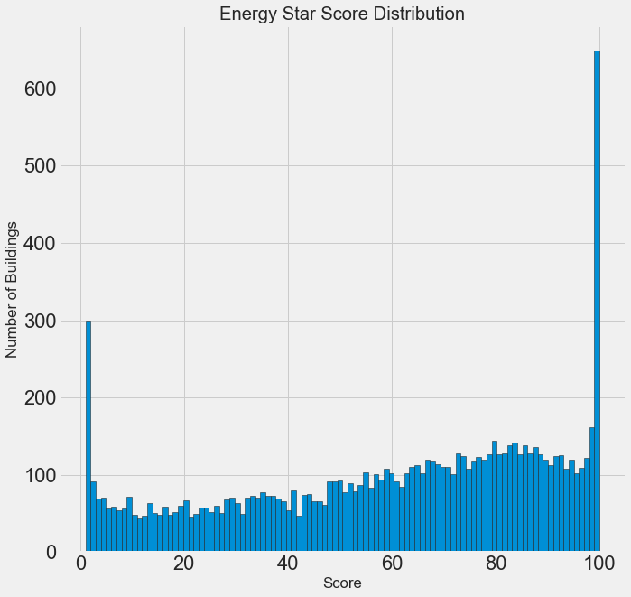

```python
figsize(10, 10)

# Rename the score
data = data.rename(columns = {'ENERGY STAR Score': 'score'})

# Histogram of the Energy Star Score
plt.style.use('fivethirtyeight')
plt.hist(data['score'].dropna(), bins =100, edgecolor = 'k');
plt.xlabel('Score'); plt.ylabel('Number of Buildings');
plt.title('Energy Star Score Distribution');
```

Выглядит подозрительно! Балл Energy Star Score является процентилем, значит следует ожидать единообразного распределения, когда каждый балл присваивается одному и тому же количеству зданий. Однако высший и низший результаты получило непропорционально большое количество зданий (для Energy Star Score чем больше, тем лучше).

Если мы снова посмотрим на определение этого балла, то увидим, что он рассчитывается на основе «самостоятельно заполняемых владельцами зданий отчётов», что может объяснить избыток очень больших значений. Просить владельцев зданий сообщать о своём энергопотреблении, это как просить студентов сообщать о своих оценках на экзаменах. Так что это, пожалуй, не самый объективный критерий оценки энергоэффективности недвижимости.

Если бы у нас был неограниченный запас времени, то можно было бы выяснить, почему так много зданий получили очень высокие и очень низкие баллы. Для этого нам пришлось бы выбрать соответствующие здания и внимательно их проанализировать. Но нам нужно только научиться прогнозировать баллы, а не разработать более точный метод оценки. Можно пометить себе, что у баллов подозрительное распределение, но мы сосредоточимся на прогнозировании.

Посмотрим распределение признака Site EUI (kBtu/ft²)

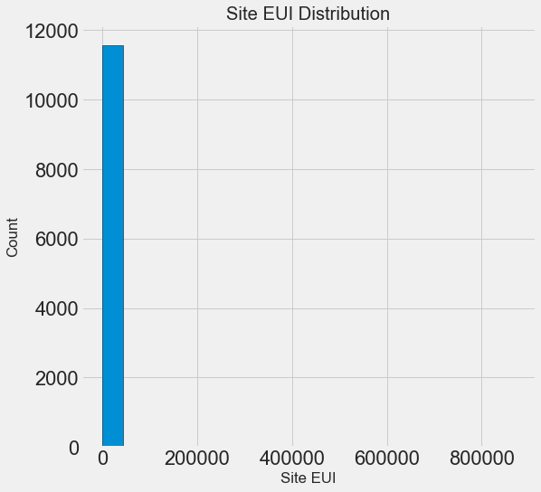

```python
# Histogram Plot of Site EUI
figsize(8, 8)
plt.hist(data['Site EUI (kBtu/ft²)'].dropna(), bins = 20, edgecolor = 'black');
plt.xlabel('Site EUI');
plt.ylabel('Count'); plt.title('Site EUI Distribution');
```

Ну, это показывает нам, что у нас есть еще одна проблема: выбросы! График невероятно искажен из-за наличия нескольких зданий с очень высокими баллами. Нам придется сделать небольшой крюк, чтобы разобраться с выбросами. Давайте посмотрим на статистику этой функции.

```python
data['Site EUI (kBtu/ft²)'].describe()
# maximum гораздо больше, чем mean - есть выбросы
```

```
count     11583.000000
mean        280.071484
std        8607.178877
min           0.000000
25%          61.800000
50%          78.500000
75%          97.600000
max      869265.000000
Name: Site EUI (kBtu/ft²), dtype: float64
```

```python
data['Site EUI (kBtu/ft²)'].dropna().sort_values().tail(10)
```

```
3173     51328.8
3170     51831.2
3383     78360.1
8269     84969.6
3263     95560.2
8268    103562.7
8174    112173.6
3898    126307.4
7       143974.4
8068    869265.0
Name: Site EUI (kBtu/ft²), dtype: float64
```

Одно здание явно намного выше остальных.

```python
data.loc[data['Order'] == 8068, :]
```

|  | Order | Property Id | Property Name | Parent Property Id | Parent Property Name | BBL - 10 digits | NYC Borough, Block and Lot (BBL) self-reported | NYC Building Identification Number (BIN) | Address 1 (self-reported) | Postal Code | Street Number | Street Name | Borough | DOF Gross Floor Area | Primary Property Type - Self Selected | List of All Property Use Types at Property | Largest Property Use Type | Largest Property Use Type - Gross Floor Area (ft²) | Year Built | Number of Buildings - Self-reported | Occupancy | Metered Areas (Energy) | Metered Areas (Water) | score | Site EUI (kBtu/ft²) | Weather Normalized Site EUI (kBtu/ft²) | Weather Normalized Site Electricity Intensity (kWh/ft²) | Weather Normalized Site Natural Gas Intensity (therms/ft²) | Weather Normalized Source EUI (kBtu/ft²) | … |
| --- | --- | --- | --- | --- | --- | --- | --- | --- | --- | --- | --- | --- | --- | --- | --- | --- | --- | --- | --- | --- | --- | --- | --- | --- | --- | --- | --- | --- | --- | --- |
| 6717 | 8068 | 5829577 | 3158 Perry Ave - 35533 | Not Applicable: Standalone Property | Not Applicable: Standalone Property | 2033450019 | 2-03345-0019 | 2018304 | 3158 Perry Avenue | 10467 | 3156 | PERRY AVENUE | Bronx | 55000.0 | Multifamily Housing | Multifamily Housing | Multifamily Housing | 55500.0 | 1925 | 1 | 100 | Whole Building | NaN | 70.0 | 90.0 | 98.6 | 3.7 | NaN | 126.6 | … |

# Удаление выбросов¶

Также на этом этапе лучше удалить аномальные значения. Они могут возникать из-за опечаток при вводе данных или из-за ошибок в единицах измерений, либо это могут быть корректные, но экстремальные значения. В данном случае мы удалим «лишние» значения, руководствуясь определением экстремальных аномалий:

- Ниже первого квартиля − 3 ∗ интерквартильный размах.
- Выше третьего квартиля + 3 ∗ интерквартильный размах.

```python
# Calculate first and third quartile
first_quartile = data['Site EUI (kBtu/ft²)'].describe()['25%']
third_quartile = data['Site EUI (kBtu/ft²)'].describe()['75%']

# Interquartile range
iqr = third_quartile - first_quartile

# Remove outliers
data = data[(data['Site EUI (kBtu/ft²)'] > (first_quartile - 3 * iqr)) &
            (data['Site EUI (kBtu/ft²)'] < (third_quartile + 3 * iqr))]
```

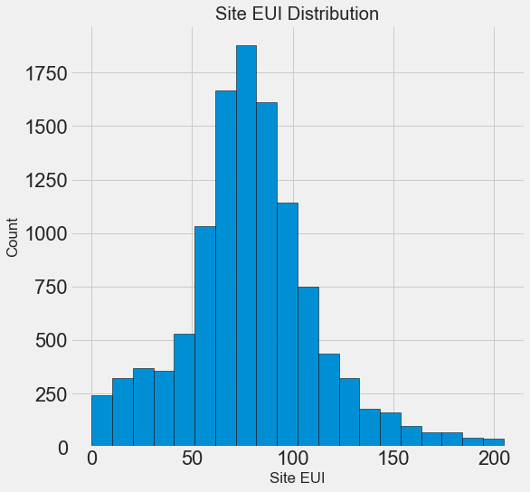

```python
# Histogram Plot of Site EUI
figsize(8, 8)
plt.hist(data['Site EUI (kBtu/ft²)'].dropna(), bins = 20, edgecolor = 'black');
plt.xlabel('Site EUI');
plt.ylabel('Count'); plt.title('Site EUI Distribution');
```

После удаления выбросов мы можем вернуться к анализу.

Этот график выглядит менее подозрительно и близок к нормально распределенному с длинным хвостом на правой стороне (он имеет положительный перекос).

### Поиск взаимосвязей

Главная часть РАД — поиск взаимосвязей между признаками и нашей целью. Коррелирующие с ней переменные полезны для использования в модели, потому что их можно применять для прогнозирования. Один из способов изучения влияния категориальной переменной (которая принимает только ограниченный набор значений) на цель — это построить график плотности с помощью библиотеки Seaborn.

График плотности можно считать сглаженной гистограммой, потому что он показывает распределение одиночной переменной. Можно раскрасить отдельные классы на графике, чтобы посмотреть, как категориальная переменная меняет распределение.

Этот код строит график плотности Energy Star Score, раскрашенный в зависимости от типа здания (для списка зданий с более чем 100 измерениями):

```python
data["Largest Property Use Type"].unique()
```

```
array(['Multifamily Housing', 'College/University',
       'Residence Hall/Dormitory', 'Office', 'Medical Office', 'Library',
       'Social/Meeting Hall', 'Other', 'Self-Storage Facility',
       'Strip Mall', 'Retail Store', 'Bank Branch', 'Movie Theater',
       'Hospital (General Medical & Surgical)', 'Enclosed Mall',
       'K-12 School', 'Other - Recreation', 'Financial Office',
       'Manufacturing/Industrial Plant', 'Performing Arts',
       'Other - Lodging/Residential', 'Hotel',
       'Non-Refrigerated Warehouse', 'Parking',
       'Other - Entertainment/Public Assembly', 'Restaurant',
       'Senior Care Community', 'Worship Facility', 'Distribution Center',
       'Urgent Care/Clinic/Other Outpatient', 'Other - Mall',
       'Other - Education', 'Museum', 'Automobile Dealership',
       'Other - Specialty Hospital', 'Residential Care Facility',
       'Outpatient Rehabilitation/Physical Therapy', 'Pre-school/Daycare',
       'Supermarket/Grocery Store', 'Mailing Center/Post Office',
       'Courthouse', 'Wholesale Club/Supercenter', 'Other - Services',
       'Other - Public Services', 'Refrigerated Warehouse',
       'Adult Education',
       'Repair Services (Vehicle, Shoe, Locksmith, etc.)',
       'Convenience Store without Gas Station'], dtype=object)
```

```python
# Create a list of buildings with more than 100 measurements
types = data.dropna(subset=['score'])
types = types['Largest Property Use Type'].value_counts()
types = list(types[types.values > 100].index)
```

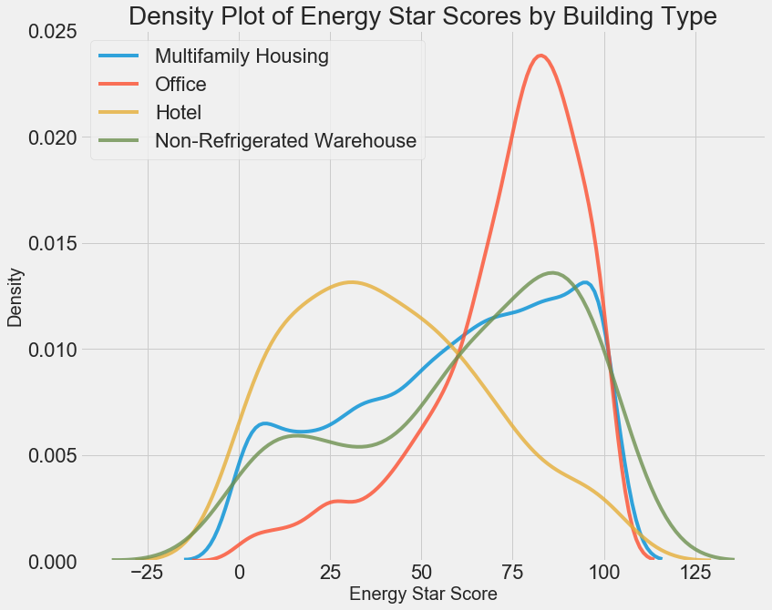

```python
# Plot of distribution of scores for building categories
figsize(12, 10)

# Plot each building
for b_type in types:
    # Select the building type
    subset = data[data['Largest Property Use Type'] == b_type]

    # Density plot of Energy Star scores
    sns.kdeplot(subset['score'].dropna(),
               label = b_type, shade = False, alpha = 0.8);

# label the plot
plt.xlabel('Energy Star Score', size = 20); plt.ylabel('Density', size = 20);
plt.title('Density Plot of Energy Star Scores by Building Type', size = 28);
```

Как видите, тип здания сильно влияет на количество баллов. Офисные здания обычно имеют более высокий балл, а отели более низкий. Значит нужно включить тип здания в модель, потому что этот признак влияет на нашу цель. В качестве категориальной переменной мы должны выполнить one-hot кодирование типа здания.

Аналогичный график можно использовать для оценки Energy Star Score по районам города:

```python
# Create a list of boroughs (районы) with more than 100 observations
boroughs = data.dropna(subset=['score'])
boroughs = boroughs['Borough'].value_counts()
boroughs = list(boroughs[boroughs.values > 100].index)
```

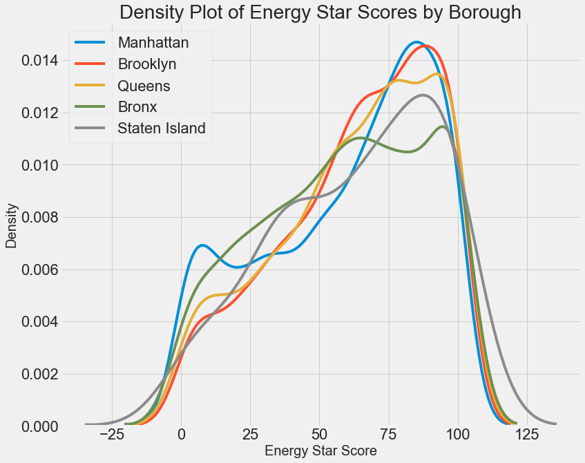

```python
# Plot of distribution of scores for boroughs
figsize(12, 10)

# Plot each borough distribution of scores
for borough in boroughs:
    # Select the building type
    subset = data[data['Borough'] == borough]

    # Density plot of Energy Star scores
    sns.kdeplot(subset['score'].dropna(),
               label = borough);

# label the plot
plt.xlabel('Energy Star Score', size = 20); plt.ylabel('Density', size = 20);
plt.title('Density Plot of Energy Star Scores by Borough', size = 28);
```

Район не так сильно влияет на балл, как тип здания. Тем не менее мы включим его в модель, потому что между районами существует небольшая разница.

### Корреляции между объектами и целью

Чтобы посчитать взаимосвязи между переменными, можно использовать коэффициент корреляции Пирсона.

Это мера интенсивности и направления линейной зависимости между двумя переменными. Значение +1 означает идеально линейную положительную зависимость, а -1 означает идеально линейную отрицательную зависимость. Хотя этот коэффициент не может отражать нелинейные зависимости, с него можно начать оценку взаимосвязей переменных.

В Pandas можно легко вычислить корреляции между любыми колонками в кадре данных (dataframe):

```python
# Find all correlations and sort
correlations_data = data.corr()['score'].sort_values()

# Print the most negative correlations
print(correlations_data.head(15), '\n')

# Print the most positive correlations
print(correlations_data.tail(15))
```

```
Site EUI (kBtu/ft²)                                          -0.723864
Weather Normalized Site EUI (kBtu/ft²)                       -0.713993
Weather Normalized Source EUI (kBtu/ft²)                     -0.645542
Source EUI (kBtu/ft²)                                        -0.641037
Weather Normalized Site Electricity Intensity (kWh/ft²)      -0.358394
Weather Normalized Site Natural Gas Intensity (therms/ft²)   -0.346046
Direct GHG Emissions (Metric Tons CO2e)                      -0.147792
Weather Normalized Site Natural Gas Use (therms)             -0.135211
Natural Gas Use (kBtu)                                       -0.133648
Year Built                                                   -0.121249
Total GHG Emissions (Metric Tons CO2e)                       -0.113136
Electricity Use - Grid Purchase (kBtu)                       -0.050639
Weather Normalized Site Electricity (kWh)                    -0.048207
Latitude                                                     -0.048196
Property Id                                                  -0.046605
Name: score, dtype: float64

Property Id                                          -0.046605
Indirect GHG Emissions (Metric Tons CO2e)            -0.043982
Longitude                                            -0.037455
Occupancy                                            -0.033215
Number of Buildings - Self-reported                  -0.022407
Water Use (All Water Sources) (kgal)                 -0.013681
Water Intensity (All Water Sources) (gal/ft²)        -0.012148
Census Tract                                         -0.002299
DOF Gross Floor Area                                  0.013001
Property GFA - Self-Reported (ft²)                    0.017360
Largest Property Use Type - Gross Floor Area (ft²)    0.018330
Order                                                 0.036827
Community Board                                       0.056612
Council District                                      0.061639
score                                                 1.000000
Name: score, dtype: float64
```

Есть несколько сильных отрицательных корреляций между признаками и целью, причём наибольшие из них относятся к разным категориям EUI (способы расчёта этих показателей слегка различаются). EUI (Energy Use Intensity, интенсивность использования энергии) — это количество энергии, потреблённой зданием, делённое на квадратный фут площади. Эта удельная величина используется для оценки энергоэффективности, и чем она меньше, тем лучше. Логика подсказывает, что эти корреляции оправданны: если EUI увеличивается, то Energy Star Score должен снижаться. Чтобы учесть возможные нелинейные связи, мы можем взять квадратный корень и естественные логарифмические преобразования признаков, а затем вычислить коэффициенты корреляции со счетом. Чтобы попытаться уловить любые возможные связи между типом района или здания (помните, что это категориальные переменные) и счетом, нам придется однократно кодировать эти столбцы.

В следующем коде мы берем логарифмические преобразования и преобразования квадратного корня числовых переменных, однократно кодируем две выбранные категориальные переменные (тип здания и район), вычисляем корреляции между всеми признаками и баллом и отображаем топ-15 самых положительных и топ-15 самых отрицательных корреляций.

```python
# Select the numeric columns
numeric_subset = data.select_dtypes('number')

# Create columns with square root and log of numeric columns
for col in numeric_subset.columns:
    # Skip the Energy Star Score column
    if col == 'score':
        next
    else:
        numeric_subset['sqrt_' + col] = np.sqrt(numeric_subset[col])
        numeric_subset['log_' + col] = np.log(numeric_subset[col])

# Select the categorical columns
categorical_subset = data[['Borough', 'Largest Property Use Type']]

# One hot encode
categorical_subset = pd.get_dummies(categorical_subset)

# Join the two dataframes using concat
# Make sure to use axis = 1 to perform a column bind
features = pd.concat([numeric_subset, categorical_subset], axis = 1)

# Drop buildings without an energy star score
features = features.dropna(subset = ['score'])

# Find correlations with the score
correlations = features.corr()['score'].dropna().sort_values()
```

```python
# Display most negative correlations
correlations.head(15)
```

```
Site EUI (kBtu/ft²)                                            -0.723864
Weather Normalized Site EUI (kBtu/ft²)                         -0.713993
sqrt_Site EUI (kBtu/ft²)                                       -0.699817
sqrt_Weather Normalized Site EUI (kBtu/ft²)                    -0.689019
sqrt_Weather Normalized Source EUI (kBtu/ft²)                  -0.671044
sqrt_Source EUI (kBtu/ft²)                                     -0.669396
Weather Normalized Source EUI (kBtu/ft²)                       -0.645542
Source EUI (kBtu/ft²)                                          -0.641037
log_Source EUI (kBtu/ft²)                                      -0.622892
log_Weather Normalized Source EUI (kBtu/ft²)                   -0.620329
log_Site EUI (kBtu/ft²)                                        -0.612039
log_Weather Normalized Site EUI (kBtu/ft²)                     -0.601332
log_Weather Normalized Site Electricity Intensity (kWh/ft²)    -0.424246
sqrt_Weather Normalized Site Electricity Intensity (kWh/ft²)   -0.406669
Weather Normalized Site Electricity Intensity (kWh/ft²)        -0.358394
Name: score, dtype: float64
```

```python
# Display most positive correlations
correlations.tail(15)
```

```
sqrt_Order                                                         0.028662
Borough_Queens                                                     0.029545
Largest Property Use Type_Supermarket/Grocery Store                0.030038
Largest Property Use Type_Residence Hall/Dormitory                 0.035407
Order                                                              0.036827
Largest Property Use Type_Hospital (General Medical & Surgical)    0.048410
Borough_Brooklyn                                                   0.050486
log_Community Board                                                0.055495
Community Board                                                    0.056612
sqrt_Community Board                                               0.058029
sqrt_Council District                                              0.060623
log_Council District                                               0.061101
Council District                                                   0.061639
Largest Property Use Type_Office                                   0.158484
score                                                              1.000000
Name: score, dtype: float64
```

После преобразования характеристик наиболее сильными остаются отношения, связанные с интенсивностью использования энергии (EUI). Преобразования логарифма и квадратного корня, по-видимому, не привели к каким-либо более сильным связям. Здесь нет сильных положительных линейных зависимостей, хотя мы видим, что тип здания офиса слабо положительно коррелирует с оценкой. Эта переменная представляет собой однократное закодированное представление категориальных переменных для типа здания.

### Двухпеременные графики

Воспользуемся диаграммами рассеивания для визуализации взаимосвязей между двумя непрерывными переменными. К цветам точек можно добавить дополнительную информацию, например, категориальную переменную. Покажем взаимосвязь Energy Star Score и EUI, цветом обозначены разные типы зданий:

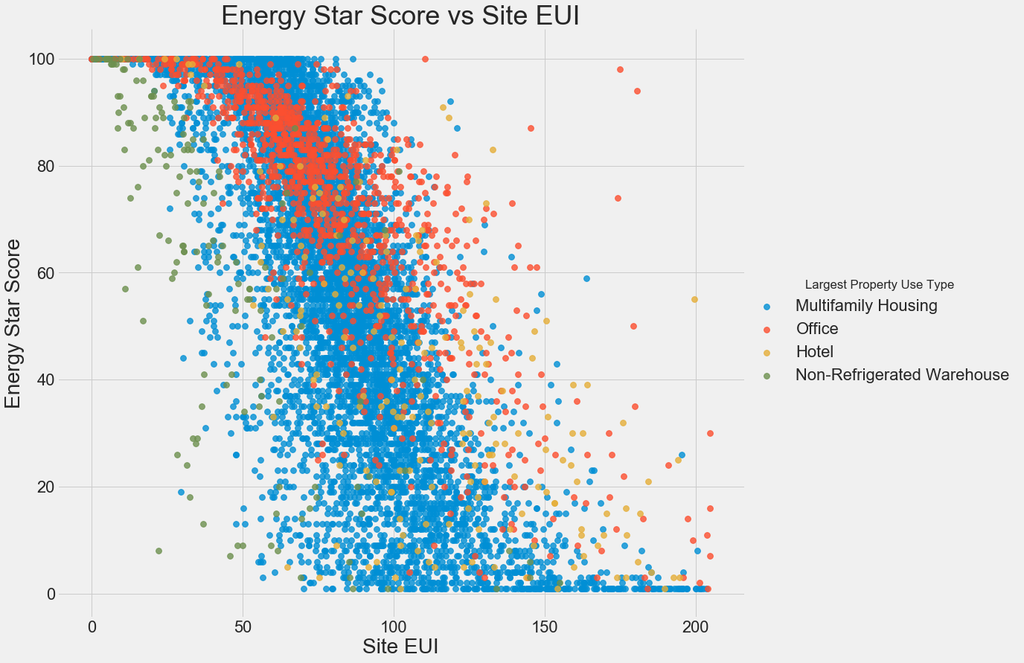

```python
figsize(12, 10)

# Extract the building types
features['Largest Property Use Type'] = data.dropna(subset = ['score'])['Largest Property Use Type']

# Limit to building types with more than 100 observations (from previous code)
features = features[features['Largest Property Use Type'].isin(types)]

# Use seaborn to plot a scatterplot of Score vs Log Source EUI
sns.lmplot('Site EUI (kBtu/ft²)', 'score',
          hue = 'Largest Property Use Type', data = features,
          scatter_kws = {'alpha': 0.8, 's': 60}, fit_reg = False,
          size = 12, aspect = 1.2);

# Plot labeling
plt.xlabel("Site EUI", size = 28)
plt.ylabel('Energy Star Score', size = 28)
plt.title('Energy Star Score vs Site EUI', size = 36);
```

Этот график позволяет визуализировать коэффициент корреляции -0,7. По мере уменьшения EUI увеличивается Energy Star Score, эта взаимосвязь наблюдается у зданий разных типов.

### Pairs Plot (парный график)

Наш последний исследовательский график называется Pairs Plot (парный график).

Это прекрасный инструмент, позволяющий увидеть взаимосвязи между различными парами переменных и распределение одиночных переменных. Мы воспользуемся библиотекой Seaborn и функцией PairGrid для создания парного графика с диаграммой рассеивания в верхнем треугольнике, с гистограммой по диагонали, двухмерной диаграммой плотности ядра и коэффициентов корреляции в нижнем треугольнике.

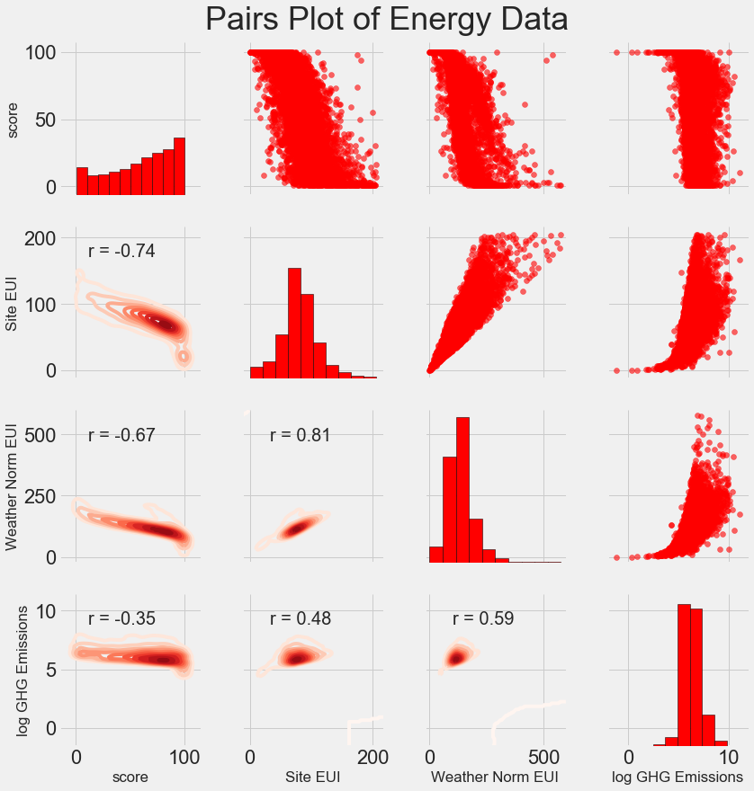

```python
# Extract the columns to  plot
plot_data = features[['score', 'Site EUI (kBtu/ft²)',
                      'Weather Normalized Source EUI (kBtu/ft²)',
                      'log_Total GHG Emissions (Metric Tons CO2e)']]

# Replace the inf with nan
plot_data = plot_data.replace({np.inf: np.nan, -np.inf: np.nan})

# Rename columns
plot_data = plot_data.rename(columns = {'Site EUI (kBtu/ft²)': 'Site EUI',
                                        'Weather Normalized Source EUI (kBtu/ft²)': 'Weather Norm EUI',
                                        'log_Total GHG Emissions (Metric Tons CO2e)': 'log GHG Emissions'})

# Drop na values
plot_data = plot_data.dropna()

# Function to calculate correlation coefficient between two columns
def corr_func(x, y, **kwargs):
    r = np.corrcoef(x, y)[0][1]
    ax = plt.gca()
    ax.annotate("r = {:.2f}".format(r),
                xy=(.2, .8), xycoords=ax.transAxes,
                size = 20)

# Create the pairgrid object
grid = sns.PairGrid(data = plot_data, size = 3)

# Upper is a scatter plot
grid.map_upper(plt.scatter, color = 'red', alpha = 0.6)

# Diagonal is a histogram
grid.map_diag(plt.hist, color = 'red', edgecolor = 'black')

# Bottom is correlation and density plot
grid.map_lower(corr_func);
grid.map_lower(sns.kdeplot, cmap = plt.cm.Reds)

# Title for entire plot
plt.suptitle('Pairs Plot of Energy Data', size = 36, y = 1.02);
```

Чтобы увидеть взаимосвязи переменных, поищем пересечения рядов и колонок. Допустим, нужно посмотреть корреляцию Weather Norm EUI и score, тогда мы ищем ряд Weather Norm EUI и колонку score, на пересечении которых стоит коэффициент корреляции -0,67. Эти графики не только хорошо выглядят, но и помогают выбрать переменные для модели.

# Конструирование признаков (Feature Engineering and Selection)

Конструирование и выбор признаков зачастую приносит наибольшую отдачу с точки зрения времени, потраченного на машинное обучение. Сначала дадим определения:

Конструирование признаков: процесс извлечения или создания новых признаков из сырых данных. Чтобы использовать переменные в модели, возможно, их придётся преобразовывать, скажем, брать натуральный логарифм, или извлекать квадратный корень, или применять one-hot кодирование категориальных переменных. Конструирование признаков можно рассматривать как создание дополнительных признаков из сырых данных.

Выбор признаков: процесс выбора из данных самых релевантных признаков, в ходе которого мы удаляем часть признаков, чтобы помочь модели лучше обобщать новые данные ради получения более интерпретируемой модели. Выбор признаков можно рассматривать как удаление «лишнего», чтобы осталось только самое важное.

Модель машинного обучения может учиться только на предоставленных нами данных, поэтому крайне важно удостовериться, что мы включили всю релевантную для нашей задачи информацию. Если не предоставить модели корректные данные, она не сможет научиться и не будет выдавать точные прогнозы!

Мы сделаем следующее:

- Применим к категориальным переменным (квартал и тип собственности) one-hot кодирование.
- Добавим взятие натурального логарифма от всех числовых переменных.

One-hot кодирование необходимо для того, чтобы включить в модель категориальные переменные. Алгоритм машинного обучения не сможет понять тип «офис», так что если здание офисное, мы присвоим ему признак 1, а если не офисное, то 0.

Добавление преобразованных признаков поможет модели узнать о нелинейных взаимосвязях внутри данных. В анализе данных является нормальной практикой извлекать квадратные корни, брать натуральные логарифмы или ещё как-то преобразовывать признаки, это зависит от конкретной задачи или вашего знания лучших методик. В данном случае мы добавим натуральный логарифм всех числовых признаков.

Выполним следующие шаги:

- выбирем числовые признаки и вычислим их логарифмы,
- выбирем два категориальных признака, применяет к ним one-hot кодирование,
- объединим оба множества в одно. Судя по описанию, предстоит куча работы, но в Pandas всё получается довольно просто!

```python
# Copy the original data
features = data.copy()

# Select the numeric columns
numeric_subset = data.select_dtypes('number')

# Create columns with log of numeric columns
for col in numeric_subset.columns:
    # Skip the Energy Star Score column
    if col == 'score':
        next
    else:
        numeric_subset['log_' + col] = np.log(numeric_subset[col])

# Select the categorical columns
categorical_subset = data[['Borough', 'Largest Property Use Type']]

# One hot encode
categorical_subset = pd.get_dummies(categorical_subset)

# Join the two dataframes using concat
# Make sure to use axis = 1 to perform a column bind
features = pd.concat([numeric_subset, categorical_subset], axis = 1)

features.shape
```

```
(11319, 110)
```

Теперь у нас есть 11 319 наблюдений (зданий) со 110 колонками (признаками). Не все признаки будут полезны для прогнозирования Energy Star Score, поэтому займёмся выбором признаков и удалим часть переменных.

## Выбор признаков

Признаки, которые сильно коррелируют друг с другом, называются коллинеарными. Удаление одной переменной в таких парах признаков часто помогает модели обобщать и быть более интерпретируемой. Обратите внимание, что речь идёт о корреляции одних признаков с другими, а не о корреляции с целью, что только помогло бы нашей модели!

Многие из имеющихся 110 признаков избыточны, потому что сильно коррелируют друг с другом. К примеру, вот график EUI и Weather Normalized Site EUI, у которых коэффициент корреляции равен 0,997.

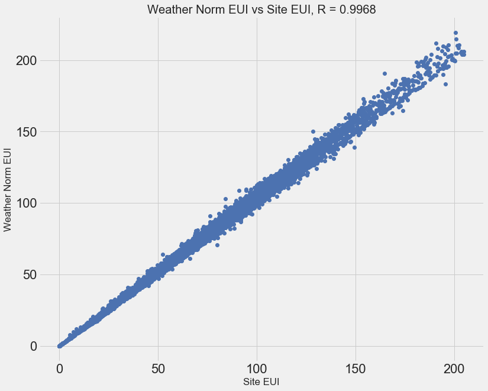

```python
plot_data = data[['Weather Normalized Site EUI (kBtu/ft²)', 'Site EUI (kBtu/ft²)']].dropna()

plt.plot(plot_data['Site EUI (kBtu/ft²)'], plot_data['Weather Normalized Site EUI (kBtu/ft²)'], 'bo')
plt.xlabel('Site EUI'); plt.ylabel('Weather Norm EUI')
plt.title('Weather Norm EUI vs Site EUI, R = %0.4f' %
          np.corrcoef(data[['Weather Normalized Site EUI (kBtu/ft²)',
                            'Site EUI (kBtu/ft²)']].dropna(), rowvar=False)[0][1]);
```

Признаки, которые сильно коррелируют друг с другом, называются коллинеарными. Удаление одной переменной в таких парах признаков часто помогает модели обобщать и быть более интерпретируемой. Обратите внимание, что речь идёт о корреляции одних признаков с другими, а не о корреляции с целью, что только помогло бы нашей модели!

Существует ряд методов вычисления коллинеарности признаков, и один из самых популярных — фактор увеличения дисперсии (variance inflation factor). Мы для поиска и удаления коллинеарных признаков воспользуемся коэффициентом В-корреляции (thebcorrelation coefficient). Отбросим одну пару признаков, если коэффициент корреляции между ними больше 0,6.

Машинное обучение эмпирично, и часто приходится экспериментировать, чтобы найти лучшее решение. После выбора у нас осталось 64 признака и одна цель.

```python
def remove_collinear_features(x, threshold):
    '''
    Objective:
        Remove collinear features in a dataframe with a correlation coefficient
        greater than the threshold. Removing collinear features can help a model
        to generalize and improves the interpretability of the model.

    Inputs:
        threshold: any features with correlations greater than this value are removed

    Output:
        dataframe that contains only the non-highly-collinear features
    '''

    # Dont want to remove correlations between Energy Star Score
    y = x['score']
    x = x.drop(columns = ['score'])

    # Calculate the correlation matrix
    corr_matrix = x.corr()
    iters = range(len(corr_matrix.columns) - 1)
    drop_cols = []

    # Iterate through the correlation matrix and compare correlations
    for i in iters:
        for j in range(i):
            item = corr_matrix.iloc[j:(j+1), (i+1):(i+2)]
            col = item.columns
            row = item.index
            val = abs(item.values)

            # If correlation exceeds the threshold
            if val >= threshold:
                # Print the correlated features and the correlation value
                # print(col.values[0], "|", row.values[0], "|", round(val[0][0], 2))
                drop_cols.append(col.values[0])

    # Drop one of each pair of correlated columns
    drops = set(drop_cols)
    x = x.drop(columns = drops)
    x = x.drop(columns = ['Weather Normalized Site EUI (kBtu/ft²)',
                          'Water Use (All Water Sources) (kgal)',
                          'log_Water Use (All Water Sources) (kgal)',
                          'Largest Property Use Type - Gross Floor Area (ft²)'])

    # Add the score back in to the data
    x['score'] = y

    return x
```

```python
# Remove the collinear features above a specified correlation coefficient
features = remove_collinear_features(features, 0.6);
```

```python
# Remove any columns with all na values
features  = features.dropna(axis=1, how = 'all')
features.shape
```

```
(11319, 65)
```

Наш окончательный набор данных теперь содержит 65 объектов (один из столбцов является целевым). Хотя большое количество объектов может быть проблематичным для таких моделей, как линейная регрессия, такие модели, как случайный лес, выполняют неявный выбор объектов и автоматически определяют, какие объекты важны. Есть и другие шаги по выбору функций, но пока мы сохраним все функции, которые у нас есть, и посмотрим, как работает модель.

# Разбиение на обучающий и тестовый наборы

Прежде чем вычислять базовый уровень, нужно разбить данные на обучающий и тестовый наборы:

1. Обучающий набор признаков — то, что мы предоставляем нашей модели вместе с ответами в ходе обучения. Модель должна выучить соответствие признаков цели.
2. Тестовый набор признаков используется для оценки обученной модели. Когда она обрабатывает тестовый набор, то не видит правильных ответов и должна прогнозировать, опираясь только на доступные признаки. Мы знаем ответы для тестовых данных и можем сравнить с ними результаты прогнозирования.

Для обучения используем 70 % данных, а для тестирования — 30 %:

```python
# Extract the buildings with no score and the buildings with a score
no_score = features[features['score'].isna()]
score = features[features['score'].notnull()]

print(no_score.shape)
print(score.shape)
```

```
(1858, 65)
(9461, 65)
```

```python
# Separate out the features and targets
features = score.drop(columns='score')
targets = pd.DataFrame(score['score'])

# Replace the inf and -inf with nan (required for later imputation)
features = features.replace({np.inf: np.nan, -np.inf: np.nan})

# Split into 70% training and 30% testing set
X, X_test, y, y_test = train_test_split(features, targets, test_size = 0.3, random_state = 42)

print(X.shape)
print(X_test.shape)
print(y.shape)
print(y_test.shape)
```

```
(6622, 64)
(2839, 64)
(6622, 1)
(2839, 1)
```

### Выбираем базовый уровень

Мы очистили данные, провели разведочный анализ и сконструировали признаки. И прежде чем перейти к созданию модели, нужно выбрать исходный базовый уровень (naive baseline) — некое предположение, с которым мы будем сравнивать результаты работы моделей. Если они окажутся ниже базового уровня, мы будем считать, что машинное обучение неприменимо для решения этой задачи, или что нужно попробовать иной подход.

Для регрессионных задач в качестве базового уровня разумно угадывать медианное значение цели на обучающем наборе для всех примеров в тестовом наборе. Эти наборы задают барьер, относительно низкий для любой модели.

### Выбор метрики. Средняя абсолютная ошибка (mae)

В качестве метрики возьмём среднюю абсолютную ошибку (mae) в прогнозах.

Для регрессий есть много других метрик, но мне нравится совет выбирать какую-то одну метрику и с её помощью оценивать модели. А среднюю абсолютную ошибку легко вычислить и интерпретировать.

```python
# Function to calculate mean absolute error
def mae(y_true, y_pred):
    return np.mean(abs(y_true - y_pred))
```

Теперь вычислим показатель для исходного базового уровня:

```python
baseline_guess = np.median(y)

print('The baseline guess is a score of %0.2f' % baseline_guess)
print("Baseline Performance on the test set: MAE = %0.4f" % mae(y_test, baseline_guess))
```

```
The baseline guess is a score of 66.00
Baseline Performance on the test set: MAE = 24.5164
```

Средняя абсолютная ошибка на тестовом наборе составила около 25 пунктов. Поскольку мы оцениваем в диапазоне от 1 до 100, то ошибка составляет 25 % — довольно низкий барьер для модели!

Сохраним полученные наборы данных

```python
# Save the no scores, training, and testing data
no_score.to_csv('data/no_score.csv', index = False)
X.to_csv('data/training_features.csv', index = False)
X_test.to_csv('data/testing_features.csv', index = False)
y.to_csv('data/training_labels.csv', index = False)
y_test.to_csv('data/testing_labels.csv', index = False)
```